**City College of San Francisco**

MATH 108 - Foundations of Data Science

# Lecture 15: Sampling

Associated Textbook Sections: [10.0, 10.1, 10.2, 10.3](https://inferentialthinking.com/chapters/10/Sampling_and_Empirical_Distributions.html)

## Set Up the Notebook

```python
from datascience import *
import numpy as np
%matplotlib inline
import matplotlib.pyplot as plots
plots.style.use('fivethirtyeight')
```

## Sampling

### Random Samples

- Deterministic sample: Sampling scheme doesn't involve chance
- Random sample:
  - Before the sample is drawn, you have to know the selection probability of every group of people in the population
  - Not all individuals / groups have to have equal chance of being selected

### Demo: Random Sampling

Load the flight delay data in `delay_july_2022.csv` sourced from the [Bureau of Transportation Statistics's Airline On-Time Performance Data](https://www.transtats.bts.gov/Tables.asp?QO_VQ=EFD&QO_anzr=Nv4yv0r%FDb0-gvzr%FDcr4s14zn0pr%FDQn6n&QO_fu146_anzr=b0-gvzr)

```python
delays = Table.read_table('data/delays_july_2022.csv')
delays
```

| MONTH | FL_DATE | OP_UNIQUE_CARRIER | ORIGIN | DEST | ARR_DELAY |
| --- | --- | --- | --- | --- | --- |
| 7 | 7/13/2022 12:00:00 AM | WN | FLL | BWI | 36 |
| 7 | 7/13/2022 12:00:00 AM | WN | FLL | CMH | -15 |
| 7 | 7/13/2022 12:00:00 AM | WN | FLL | DAL | -3 |
| 7 | 7/13/2022 12:00:00 AM | WN | FLL | DAL | -27 |
| 7 | 7/13/2022 12:00:00 AM | WN | FLL | DCA | -2 |
| 7 | 7/13/2022 12:00:00 AM | WN | FLL | DCA | -12 |
| 7 | 7/13/2022 12:00:00 AM | WN | FLL | HOU | 6 |
| 7 | 7/13/2022 12:00:00 AM | WN | FLL | HOU | -12 |
| 7 | 7/13/2022 12:00:00 AM | WN | FLL | HOU | 8 |
| 7 | 7/13/2022 12:00:00 AM | WN | FLL | IND | 9 |

... (594947 rows omitted)

Narrow the data to flights that have left from SFO.

```python
sfo_delays = delays.where('ORIGIN', 'SFO').drop(0, 1, 2, 3).relabeled('ARR_DELAY', 'DELAY')
sfo_delays
```

| DEST | DELAY |
| --- | --- |
| BUR | -18 |
| BUR | -13 |
| BUR | -7 |
| BUR | -6 |
| BUR | -16 |
| BUR | nan |
| DEN | -18 |
| DEN | -14 |
| DEN | 66 |
| LAS | 10 |

... (11806 rows omitted)

Demonstrate how to use the `take` method to systematically sample the data.

```python
sfo_delays.take(np.arange(0, sfo_delays.num_rows, 1000))
```

| DEST | DELAY |
| --- | --- |
| BUR | -18 |
| DAL | -4 |
| PSP | -11 |
| AUS | 2 |
| SEA | -26 |
| DTW | -26 |
| LAX | -9 |
| BOS | -35 |
| DEN | -26 |
| BOS | 63 |

... (2 rows omitted)

Use `np.random.choice` introduce an element of chance into the sampling process.

```python
start = np.random.choice(np.arange(1000))
sfo_delays.take(np.arange(start, sfo_delays.num_rows, 1000))
```

| DEST | DELAY |
| --- | --- |
| AUS | -17 |
| FAT | -27 |
| PHX | 84 |
| IAH | -19 |
| JFK | 49 |
| LAX | -10 |
| PHX | 7 |
| ORD | 84 |
| DFW | 10 |
| SEA | -19 |

... (2 rows omitted)

### Sample of Convenience

- Example: sample consists of whoever walks by
- Just because you think you're sampling "randomly", doesn't mean you have a random sample.
- If you can't figure out the following ahead of time, then you don't have a random sample
  - what's the population
  - what's the chance of selection, for each group in the population

## Distrubtions

### Probability Distribution

- Random quantity with various possible values
- Probability Distribution:
  - All the possible values of the quantity
  - The probability of each of those values
- If you can do the math, you can work out the probability distribution without ever simulating it
- But... simulation is often easier!

### Empirical Distribution

- Empirical: based on observations
- Observations can be from repetitions of an experiment
- Empirical Distribution:
  - All observed values
  - The proportion of times each value appears

### Demo: Distributions

Create a table with the face numbers of a six-sided die. Use that table with the `sample` method to simulate randomly rolling a die. Visualize the empirical distribution.

```python
die = Table().with_column('Face', np.arange(1,7))
die
```

| Face |
| --- |
| 1 |
| 2 |
| 3 |
| 4 |
| 5 |
| 6 |

```python
die.sample(1)
```

| Face |
| --- |
| 5 |

```python
#die.sample(with_replacement=True)
die.sample()
```

| Face |
| --- |
| 2 |
| 5 |
| 1 |
| 6 |
| 1 |
| 4 |

```python
die.sample(with_replacement=False)
```

| Face |
| --- |
| 4 |
| 1 |
| 2 |
| 6 |
| 5 |
| 3 |

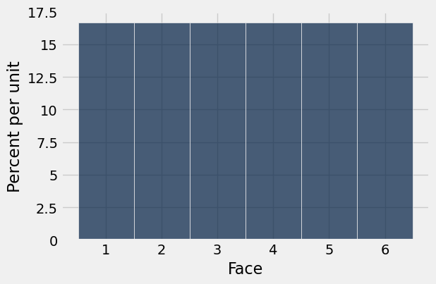

```python
die.hist(bins=np.arange(0.5, 6.6))
```

Update the bins and randomly sample for a few different sample sizes.

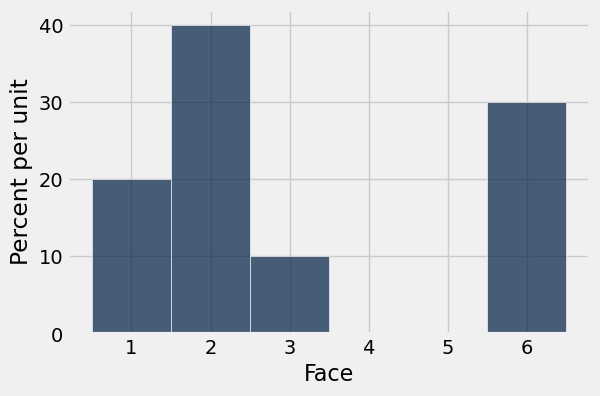

```python
die.sample(10).hist(bins=np.arange(0.5, 6.6))
```

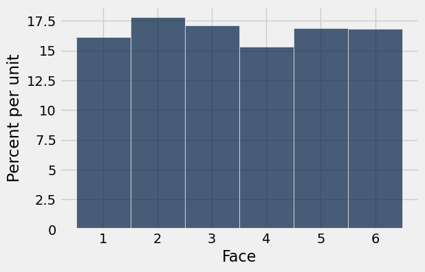

```python
die.sample(1000).hist(bins=np.arange(0.5, 6.6))
```

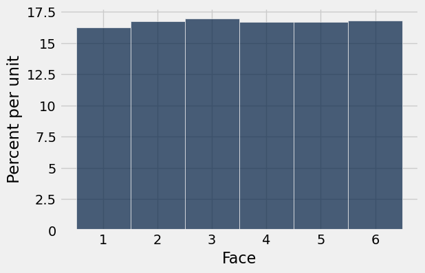

```python
die.sample(10000).hist(bins=np.arange(0.5, 6.6))
```

## Large Random Samples

### Law of Averages / Law of Large Numbers

- If a chance experiment is repeated many times, independently and under the same conditions, then the proportion of times that an event occurs gets closer to the theoretical probability of the event
- As you increase the number of rolls of a six-sided die, the proportion of times you see the face with five spots gets closer to 1/6

### Empirical Distribution of a Sample

If the sample size is large, then the empirical distribution of a uniform random sample resembles the distribution of the population, with high probability.

### Demo: Large Random Samples

```python
sfo_delays = sfo_delays.sort('DELAY', True)
sfo_delays
```

| DEST | DELAY |
| --- | --- |
| BUR | nan |
| DEN | nan |
| DEN | nan |
| MDW | nan |
| BUR | nan |
| DEN | nan |
| DEN | nan |
| LAS | nan |
| PHX | nan |
| LAS | nan |

... (11806 rows omitted)

```python
nan_filter = np.invert(np.isnan(sfo_delays.column('DELAY'))) # Extra concept/not required
nan_filter
```

```
array([False, False, False, ...,  True,  True,  True], dtype=bool)
```

```python
sfo_delays = sfo_delays.where(nan_filter)
sfo_delays
```

| DEST | DELAY |
| --- | --- |
| LAS | 1311 |
| MIA | 1264 |
| BIH | 1227 |
| DEN | 1217 |
| DFW | 1197 |
| ORD | 1085 |
| DFW | 1073 |
| AUS | 994 |
| IAH | 987 |
| LAS | 960 |

... (11651 rows omitted)

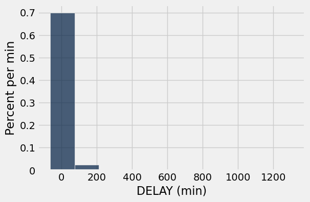

```python
sfo_delays.hist('DELAY', unit='min')
```

```python
-min(sfo_delays.column('DELAY'))
```

```
64.0
```

```python
-max(sfo_delays.column('DELAY'))
```

```
-1311.0
```

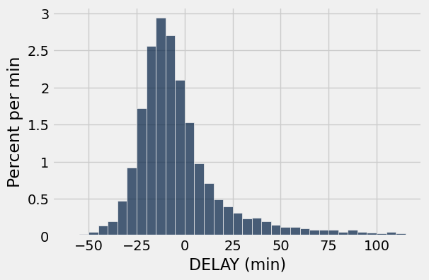

```python
sfo_delays.hist('DELAY', unit='min', bins=np.arange(-60, 120, 5))
```

```python
sfo_delays_typ = sfo_delays.where('DELAY', are.between_or_equal_to(-60, 120))
```

Randomly sample 10 and 1000 flights from the delay data and visualize the distributions of the samples.

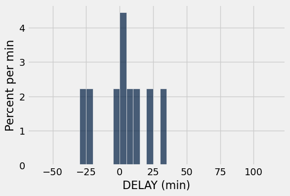

```python
sfo_delays.sample(10).hist('DELAY', unit='min', bins=np.arange(-60, 120, 5))
```

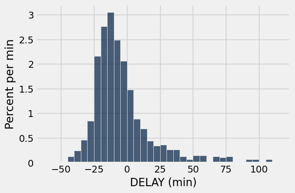

```python
sfo_delays.sample(1000).hist('DELAY', unit='min', bins=np.arange(-60, 120, 5))
```

## A Statistic

### Inference

- Statistical Inference: Making conclusions based on data in random samples
- Example: Use the data to guess the value of an unknown and fixed number by creating an estimate of the unknown quantity that depends on the random sample.

### Terminology

- Parameter: A number associated with the population
- Statistic: A number calculated from the sample
- A statistic can be used as an estimate of a parameter

### Demo: Simulating Statistics

Calculate the median parameter for the flight delays and compare it to the median statistic associated with a random sample of 10 flights.

```python
np.median(sfo_delays_typ.column('DELAY')) #parameter
```

```
-9.0
```

```python
np.median(sfo_delays_typ.sample(10).column('DELAY')) #statistic
```

```
-12.0
```

```python
np.median(sfo_delays_typ.sample(1000).column('DELAY')) #statistic
```

```
-9.0
```

Define a function that randomly samples delay data for an inputted sample size and returns the median delay for that sample.

```python
def sample_median(size):
    return np.median(sfo_delays_typ.sample(size).column('DELAY')) #statistic
```

```python
sample_median(100)
```

```
-10.5
```

Simulate randomly sampling 10 flights 1000 times and storing the sample delay medians for each iteration. Add the results to a table and visualize the sampling distribution.

```python
sample_medians = make_array()
size = 10

for _ in np.arange(1000):
    new_median = sample_median(size)
    sample_medians = np.append(sample_medians, new_median)
```

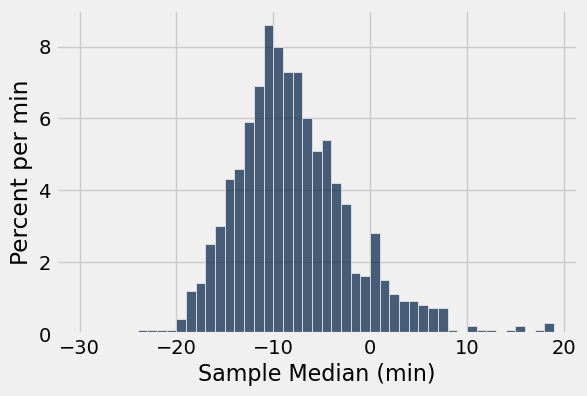

```python
Table().with_column('Sample Median', sample_medians).hist(bins = np.arange(-30, 20), unit='min')
```

Repeat the sample simulation except use a sample size of 1000, instead of 10.

```python
sample_medians = make_array()
size = 1000

for _ in np.arange(1000):
    new_median = sample_median(size)
    sample_medians = np.append(sample_medians, new_median)
```

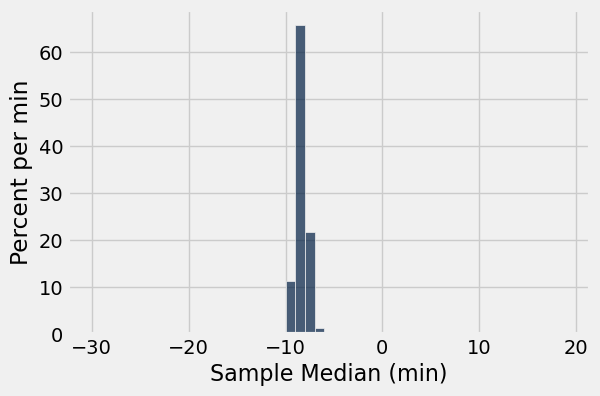

```python
Table().with_column('Sample Median', sample_medians).hist(bins = np.arange(-30, 20), unit='min')
```

### Probability Distribution of a Statistic

- Values of a statistic vary because random samples vary
- Sampling distribution (or probability distribution) of the statistic:
  - All possible values of the statistic,
  - and all the corresponding probabilities
  - Can be hard to calculate
    - Either have to do the math
    - Or have to generate all possible samples and calculate the statistic based on each sample

### Empirical Distribution of a Statistic

- Empirical distribution of the statistic:
  - Based on simulated values of the statistic
  - Consists of all the observed values of the statistic,
  - and the proportion of times each value appeared
- Good approximation to the probability distribution of the statistic if the number of repetitions in the simulation is large